# Maximum Likelihood in R

## Overview

- Probability vs Likelihood
- Examples with Binomial and Normal functions
- Searching for Maximum Likelihood with R
- Avoiding local maxima

## Probability vs Likelihood

## Probability

- Imagine that you give someone a memory test containing 20 items
- They can either get the item correct or incorrect
- You want to figure out what is the probability that the person will get 12 items correct *assuming that they have a 70% chance of producing a correct answer*.
- We can use a binomial model where \(n = 20\) and \(p = .7\)

\[ K \sim \mbox{Binomial}(n, p) %p(k; n, p) = {n \choose k} p^k(1-p)^{n-k} \]

## Binomial Probability

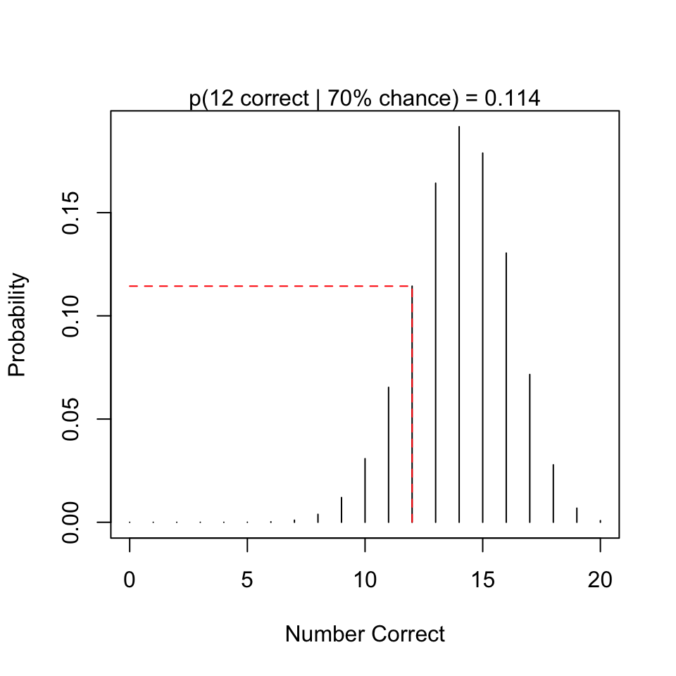

\[ p(12; 20, 0.7) = {20 \choose 12} 0.7^{12}0.3^{8} \]

Or in `R`

```r
dbinom(x = 12, size = 20, prob = 0.7)
```

```
## [1] 0.1143967
```

## Likelihood

But!

- Usually (all the time) we don't know the 'true' probability of a correct response
- Rather we try to *estimate* it from data
- Back to the example:
  - we have given someone a 20 item memory test and they got 12 correct
  - what is the most probable value of their 'true' accuracy?
  - For that we need the *likelihood*

## Likelihood

Switch the data and the parameters.

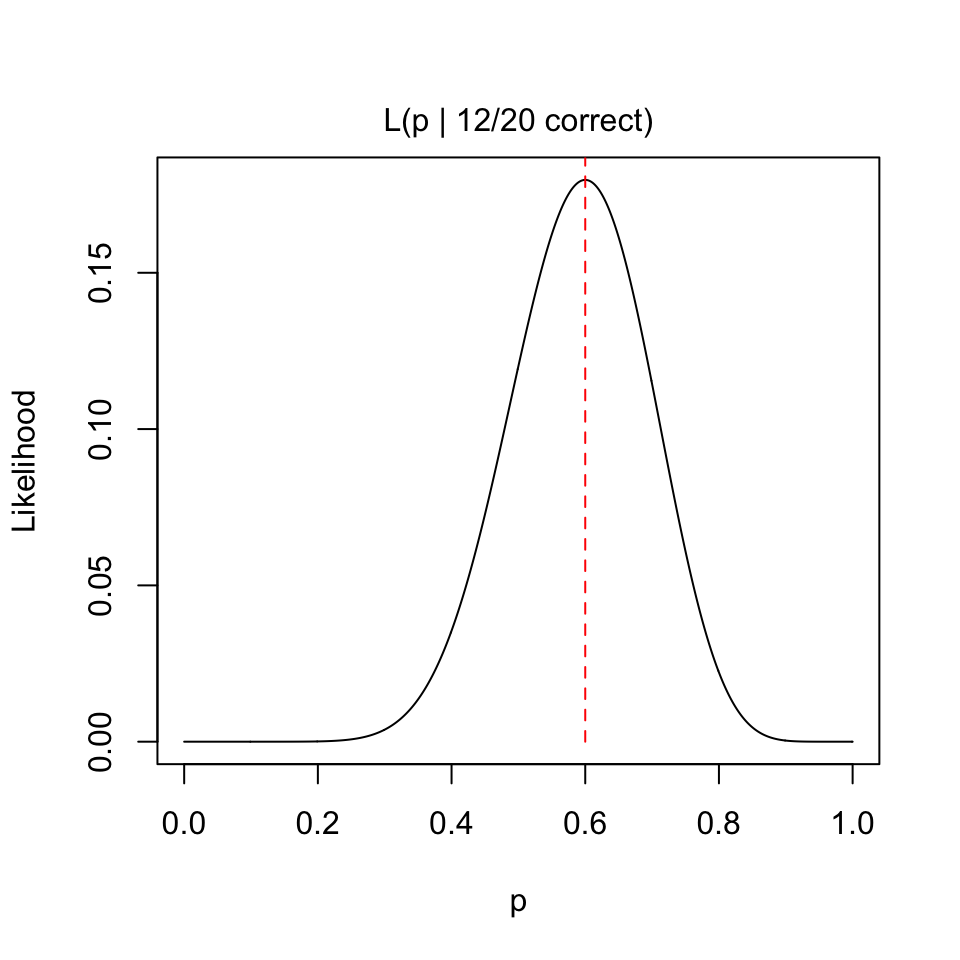

## Examples

## Normal Distribution

Here is the Normal probability density function for \(\mu = 0\) and \(\sigma = 1\).

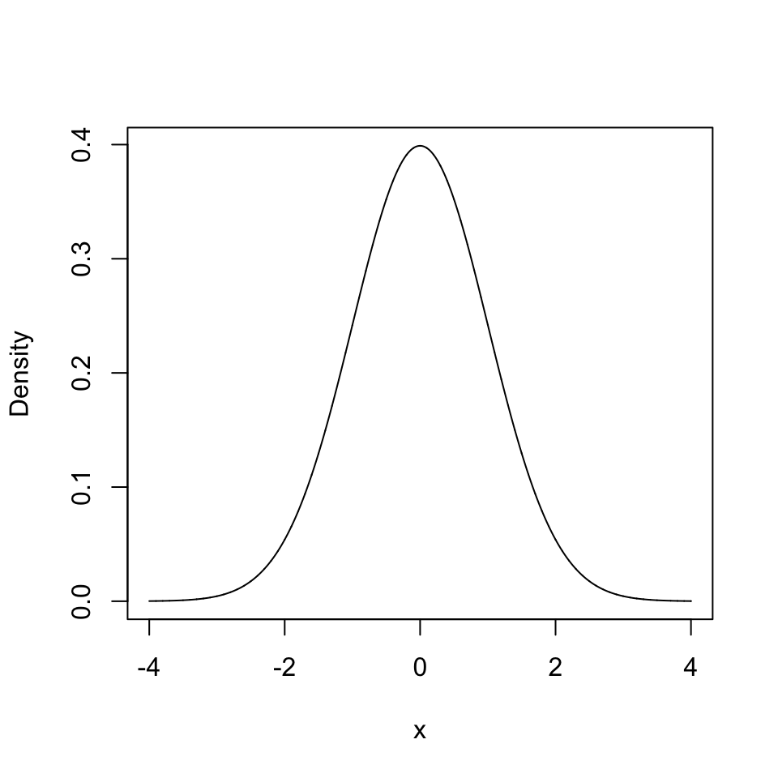

## Example with a Normal likelihood function

Here's some data

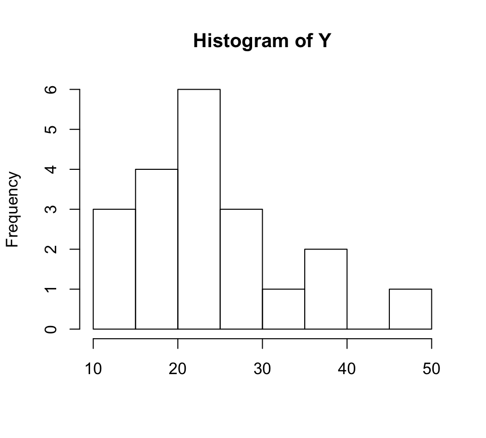

## Example - known SD

Let's assume that we know that \(\sigma = 1\). What's the most likely value of \(\mu\) for the first observation (Y[1] = 29.060444)?

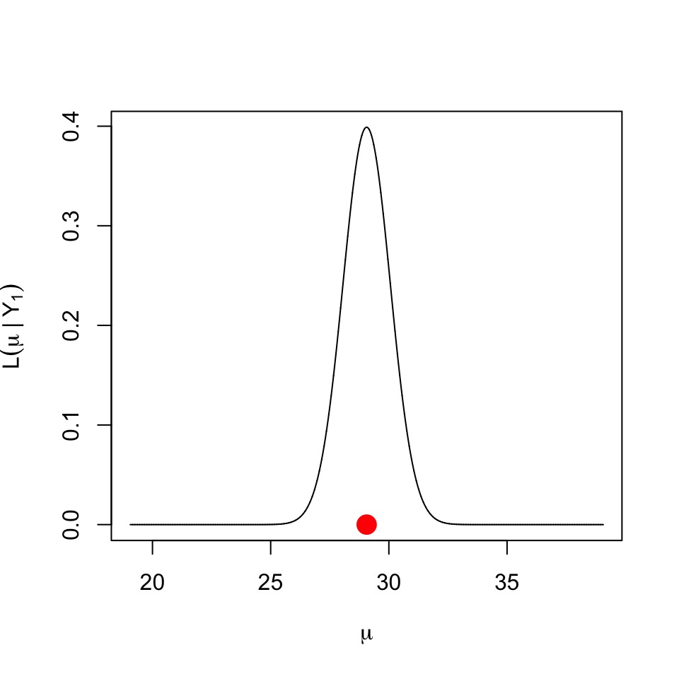

## Example - known SD

- But we have a *vector* of observations!
- Assuming the observations are independent we can multiply each of the likelihoods
- In our case \(\theta = \{\mu, \sigma\}\)

\[ L(\mathbf{\theta \mid y}) = \prod^i L(\theta \mid y_i) \]

## Example - known SD

- It's more common to work with the *log likelihood* (\(LL\)) so instead we can sum
- We'll go into more detail on this later

\[ LL(\theta \mid \mathbf{y}) = \sum^i \ln L(\theta \mid y_i) \]

## Example - known SD

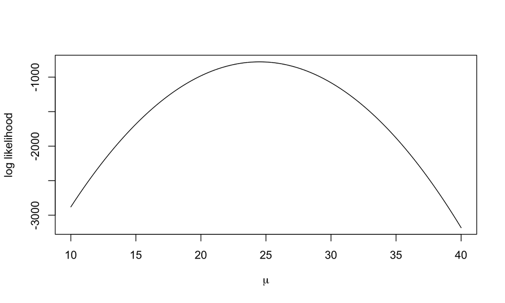

## Example - unknown mean and SD

What if we don't know either \(\mu\) or \(\sigma\)? The we have to search for the *pair* of parameters that maximize the likelihood.

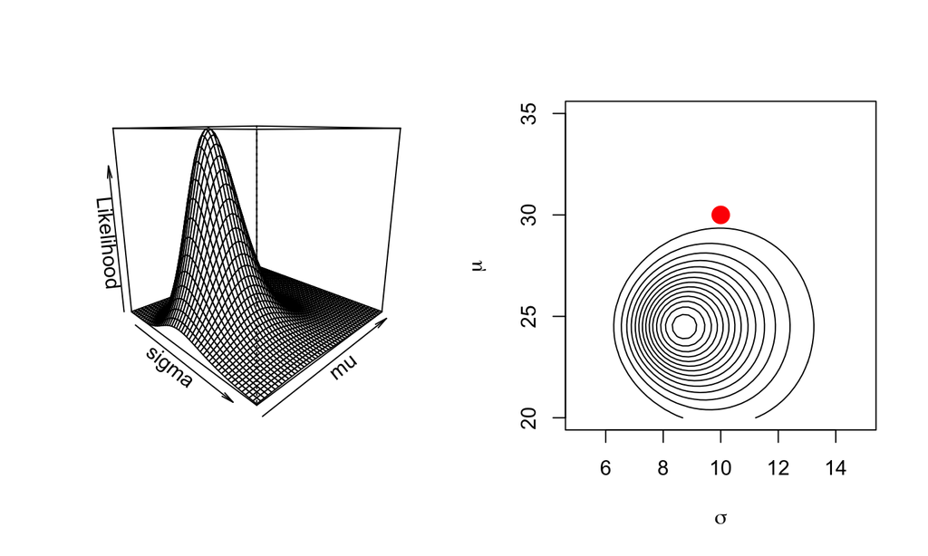

## Searching for Maximum Likelihood with R

## Details

- When using maximum likelihood estimation you typically actually try to *minimize* the negative log likelihood
- `optim()` is a general-purpose function for finding parameter values that minimize \(-LL\)

## Example

- Let's return to the previous example with our data.
- To follow along you can type:

```r
# rnorm generates (pseudo) random numbers from a normal distribution
set.seed(2468)
Y = rnorm(n = 20, mean = 30, sd = 10)
Y
```

```
##  [1] 29.06044 26.80808 22.44365 34.58982 37.01713 13.75688 18.51156
##  [8] 12.56390 22.52882 22.55374 24.55997 18.99216 24.17542 48.07603
## [15] 20.61024 18.22652 12.70438 27.98661 35.18324 19.63128
```

## Example

- First we need a function that returns the log likelihood of parameters given the data

```r
ll_norm = function(theta, y){
  mu = theta[1]
  sigma = theta[2]
  ll = 0
  for (i in y){
    # dnorm returns the density of a normal for a particular value (x) mean and
    # standard deviation. Setting log = T gives us the LL
    ll = ll + dnorm(x = i, mean = mu, sd = sigma, log = T)
  }
  return(-ll) # note the negative
}
```

## Example

```r
# starting values
theta = runif(n = 2, min = 1, max = 10)

# run the optimization
out = optim(par = theta, fn = ll_norm, y = Y)

# assess the parameter estimates
out$par
```

```
## [1] 24.499454  8.714576
```

## Avoiding local maxima

## Avoiding local maxima

- With many parameters (dimensions) there may be troughs in the likelihood function that are not the global maximum likelihood
- These are called local maxima and optimizers can get stuck there (therefore, not providing the *maximum* likelihood estimates)

## Try multiple starting values

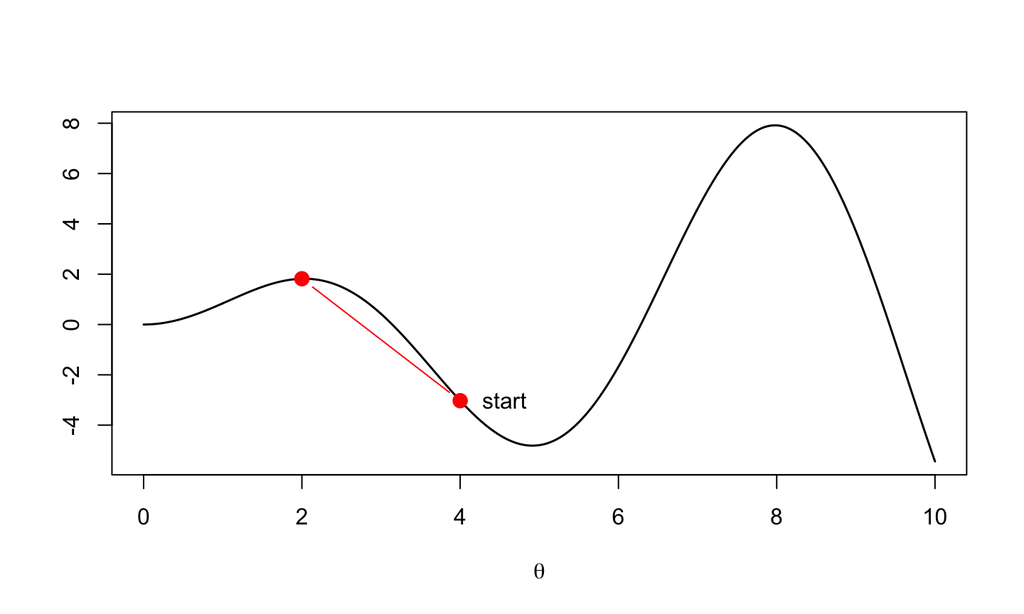

## Try multiple starting values

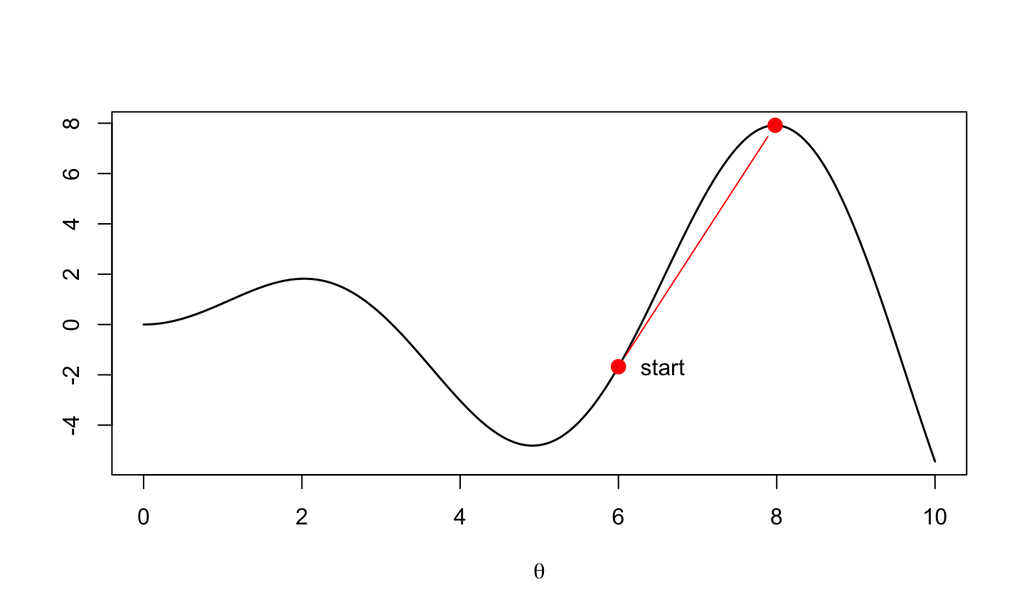

## Try different optimizers

- There are lots of different optimization routines (see, e.g., `?optim`)
- One approach is to pass the results of a first `optim` run to `nlm` then back to `optim`

```r
theta = runif(n = 2, min = 1, max = 10)

out = optim(par = theta, fn = ll_norm, y = Y)
out2 = nlm(f = ll_norm, p = out$par, y = Y)
out3 = optim(par = out2$estimate, fn = ll_norm, y = Y)

# compare estimates
cbind(out$par, out2$estimate, out3$par)
```

```
##           [,1]      [,2]      [,3]
## [1,] 24.500167 24.498981 24.498981
## [2,]  8.716571  8.718215  8.718215
```

## Extra Slides

## Alternative likelihood function

You can often avoid using `for` loops in `R`. Below we have rewritten the `ll_norm` function, replacing the loop with `mapply` (see `?mapply`).

```r
ll_norm = function(theta, y){
  mu = theta[1]
  sigma = theta[2]
  ll = sum(mapply(y, FUN = function(x) dnorm(x = x, mean = mu, sd = sigma, log = T)))
  return(-ll)
}
```

## Alternative likelihood function

```r
ll_norm = function(theta, y){
  mu = theta[1]
  sigma = theta[2]
  ll = sum(dnorm(x = y, mean = mu, sd = sigma, log = T))
  return(-ll)
}
```